# ML_Capstone_Ben

Benarivo

28/03/2020

```r
library(tidyverse)
```

```r
library(ggplot2)
library(dplyr)
library(forecast)
library(purrr)
library(yardstick)
library(lubridate)
library(recipes)
library(magrittr)
library(plotly)
library(MLmetrics)
```

# 1. Data Preprocess

Firstly, we will need to load the data and explore it.

```r
scotty <- read.csv("data/data-train.csv")
```

```r
head(scotty)
```

```
##                         id                  trip_id                driver_id
## 1 59d005e1ffcfa261708ce9cd 59d005e9cb564761a8fe5d3e 59a892c5568be44b2734f276
## 2 59d0066affcfa261708ceb11                     <NA>                     <NA>
## 3 59d006a1ffcfa261708ceba4 59d006c131e39c618969343d 599dc0dfa5b4fd5471ad8453
## 4 59d006d8cb564761a8fe5efd 59d007193d32b861760d4a77 59a5856573d56e7103b5d51d
## 5 59d0073ecb564761a8fe5fdc                     <NA>                     <NA>
## 6 59d007c3ffcfa261708ceee1 59d007de31e39c618969354f 599dc0dfa5b4fd5471ad8453
##                   rider_id           start_time  src_lat  src_lon src_area
## 1 59ad2d6efba75a581666b506 2017-10-01T00:00:17Z 41.07047 29.01945     sxk9
## 2 59cd704bcf482f6ce2fadfdb 2017-10-01T00:02:34Z 41.07487 28.99528     sxk9
## 3 59bd62cc7e3c3b663924ba86 2017-10-01T00:03:29Z 41.04995 29.03107     sxk9
## 4 59c17cd1f6da2d274e16d0a7 2017-10-01T00:04:24Z 41.05287 28.99522     sxk9
## 5 596f47a8a294a82ea3e90e77 2017-10-01T00:06:06Z 41.06760 28.98827     sxk9
## 6 59bd62cc7e3c3b663924ba86 2017-10-01T00:08:19Z 41.04995 29.03107     sxk9
##   src_sub_area dest_lat dest_lon dest_area dest_sub_area  distance    status
## 1        sxk9s 41.11716 29.03650      sxk9         sxk9u  5.379250 confirmed
## 2        sxk9e 41.08351 29.00228      sxk9         sxk9e  1.126098 nodrivers
## 3        sxk9s 41.04495 28.98192      sxk9         sxk9e  4.169492 confirmed
## 4        sxk9e 41.08140 28.98197      sxk9         sxk9e  3.358296 confirmed
## 5        sxk9e 41.02125 29.11316      sxk9         sxk9q 11.693573 nodrivers
## 6        sxk9s 41.04495 28.98192      sxk9         sxk9e  4.169492 confirmed
##   confirmed_time_sec
## 1                  8
## 2                  0
## 3                 32
## 4                 65
## 5                  0
## 6                 27
```

Based on above exploration, ‘start_time’ should be changed from factor to date.

```r
scotty$start_time <- ymd_hms(scotty$start_time)
```

```r
head(scotty)
```

```
##                         id                  trip_id                driver_id
## 1 59d005e1ffcfa261708ce9cd 59d005e9cb564761a8fe5d3e 59a892c5568be44b2734f276
## 2 59d0066affcfa261708ceb11                     <NA>                     <NA>
## 3 59d006a1ffcfa261708ceba4 59d006c131e39c618969343d 599dc0dfa5b4fd5471ad8453
## 4 59d006d8cb564761a8fe5efd 59d007193d32b861760d4a77 59a5856573d56e7103b5d51d
## 5 59d0073ecb564761a8fe5fdc                     <NA>                     <NA>
## 6 59d007c3ffcfa261708ceee1 59d007de31e39c618969354f 599dc0dfa5b4fd5471ad8453
##                   rider_id          start_time  src_lat  src_lon src_area
## 1 59ad2d6efba75a581666b506 2017-10-01 00:00:17 41.07047 29.01945     sxk9
## 2 59cd704bcf482f6ce2fadfdb 2017-10-01 00:02:34 41.07487 28.99528     sxk9
## 3 59bd62cc7e3c3b663924ba86 2017-10-01 00:03:29 41.04995 29.03107     sxk9
## 4 59c17cd1f6da2d274e16d0a7 2017-10-01 00:04:24 41.05287 28.99522     sxk9
## 5 596f47a8a294a82ea3e90e77 2017-10-01 00:06:06 41.06760 28.98827     sxk9
## 6 59bd62cc7e3c3b663924ba86 2017-10-01 00:08:19 41.04995 29.03107     sxk9
##   src_sub_area dest_lat dest_lon dest_area dest_sub_area  distance    status
## 1        sxk9s 41.11716 29.03650      sxk9         sxk9u  5.379250 confirmed
## 2        sxk9e 41.08351 29.00228      sxk9         sxk9e  1.126098 nodrivers
## 3        sxk9s 41.04495 28.98192      sxk9         sxk9e  4.169492 confirmed
## 4        sxk9e 41.08140 28.98197      sxk9         sxk9e  3.358296 confirmed
## 5        sxk9e 41.02125 29.11316      sxk9         sxk9q 11.693573 nodrivers
## 6        sxk9s 41.04495 28.98192      sxk9         sxk9e  4.169492 confirmed
##   confirmed_time_sec
## 1                  8
## 2                  0
## 3                 32
## 4                 65
## 5                  0
## 6                 27
```

Then, we need to floor the ‘start_time’ to hours and save it as ‘datetime’.

```r
scotty <- scotty %>%
   mutate(datetime = floor_date(start_time, unit ="hour"))

tail(scotty)
```

```
##                             id                  trip_id
## 90108 5a2313b99af1344c65bdcd23 5a2313d4ecb4a04c668715b4
## 90109 5a2313c9ecb4a04c66871562 5a231405ecb4a04c66871760
## 90110 5a23140c9af1344c65bdcfcc 5a231418490a204c2d2e4fe3
## 90111 5a23140f490a204c2d2e4f64 5a2314179af1344c65bdd026
## 90112 5a231413ecb4a04c668717d6 5a23141aecb4a04c66871813
## 90113 5a2314289af1344c65bdd0b2 5a231452490a204c2d2e52b3
##                      driver_id                 rider_id          start_time
## 90108 5a0f6170df25ec7cf5c9f89a 59f0ee1ae2e1cd3a3a9f484d 2017-12-02 23:57:29
## 90109 59dcf95539a56e667e8acfab 5a0060b4954e5279e1f54b74 2017-12-02 23:57:45
## 90110 59e9cee888b70d3a340fe3eb 59aea08ffba75a5816724b92 2017-12-02 23:58:52
## 90111 5a12f04bdf25ec7cf5d36a53 59a443fa96eb142b5301c5f2 2017-12-02 23:58:55
## 90112 58f51cdc033e9c2b83808baf 5a0060b4954e5279e1f54b74 2017-12-02 23:58:59
## 90113 59e63589f4cec50c579adb46 59c011eae3772666232aa7ef 2017-12-02 23:59:20
##        src_lat  src_lon src_area src_sub_area dest_lat dest_lon dest_area
## 90108 41.00904 28.96596     sxk9        sxk97 41.00590 29.12500      sxk9
## 90109 41.05580 29.00971     sxk9        sxk9s 41.10510 28.98750      sxk9
## 90110 41.03249 28.98235     sxk9        sxk97 41.01060 28.97569      sxk9
## 90111 41.06734 28.99231     sxk9        sxk9e 41.07263 28.91610      sxk9
## 90112 41.05580 29.00971     sxk9        sxk9s 41.10510 28.98750      sxk9
## 90113 41.06807 28.99281     sxk9        sxk9e 41.07171 28.96040      sxk9
##       dest_sub_area  distance    status confirmed_time_sec            datetime
## 90108         sxk9q 13.383999 confirmed                 27 2017-12-02 23:00:00
## 90109         sxk9g  5.783793 confirmed                 60 2017-12-02 23:00:00
## 90110         sxk97  2.495586 confirmed                 12 2017-12-02 23:00:00
## 90111         sxk9d  6.431619 confirmed                  8 2017-12-02 23:00:00
## 90112         sxk9g  5.783793 confirmed                  7 2017-12-02 23:00:00
## 90113         sxk9e  2.753564 confirmed                 42 2017-12-02 23:00:00
```

Because we need to analyse the data hourly demand per area ‘src_sub_area’, the data should be groupped by ‘src_sub_area’ and ‘datetime’

```r
scotty <- scotty %>%
   group_by(src_sub_area,datetime) %>%
   summarise(demand = n()) #n or n_distinct

head(scotty)
```

```
## # A tibble: 6 x 3
## # Groups:   src_sub_area [1]
##   src_sub_area datetime            demand
##   <fct>        <dttm>               <int>
## 1 sxk97        2017-10-01 00:00:00      6
## 2 sxk97        2017-10-01 01:00:00      4
## 3 sxk97        2017-10-01 02:00:00      9
## 4 sxk97        2017-10-01 03:00:00      2
## 5 sxk97        2017-10-01 04:00:00      5
## 6 sxk97        2017-10-01 05:00:00      4
```

Based of above exploration, there are times when there is no demand, for example at 2017-10-01 on 07:00:00. Therefore, we need to do time series padding, to set the demand to zero when there is no demand.

Firstly, we set the interval of the time series padding, which is the same interval of our full data.

```r
min_date <- min(scotty$datetime)
max_date <- max(scotty$datetime)
inpad <- interval(min_date,max_date)
inpad
```

```
## [1] 2017-10-01 UTC--2017-12-02 23:00:00 UTC
```

The time series padding interval is from 2017-10-01 00:00:00 until 2017-12-02 23:00:00. Then, the data is padded using the interval.

```r
scotty <- scotty %>%
   padr::pad(start_val=min_date, end_val=max_date)
```

```
## pad applied on the interval: hour
```

```r
head(scotty)
```

```
## # A tibble: 6 x 3
## # Groups:   src_sub_area [1]
##   src_sub_area datetime            demand
##   <fct>        <dttm>               <int>
## 1 sxk97        2017-10-01 00:00:00      6
## 2 sxk97        2017-10-01 01:00:00      4
## 3 sxk97        2017-10-01 02:00:00      9
## 4 sxk97        2017-10-01 03:00:00      2
## 5 sxk97        2017-10-01 04:00:00      5
## 6 sxk97        2017-10-01 05:00:00      4
```

As seen above, we already have the ‘datetime’ data for when there is no demand. However, the data is still NA, this is proven as shown below that there is an NA data.

```r
anyNA(scotty)
```

```
## [1] TRUE
```

Now, we need to replace the NA to zero.

```r
scotty <- scotty %>%
   mutate(demand = replace_na(demand,0))

anyNA(scotty)
```

```
## [1] FALSE
```

```r
head(scotty)
```

```
## # A tibble: 6 x 3
## # Groups:   src_sub_area [1]
##   src_sub_area datetime            demand
##   <fct>        <dttm>               <dbl>
## 1 sxk97        2017-10-01 00:00:00      6
## 2 sxk97        2017-10-01 01:00:00      4
## 3 sxk97        2017-10-01 02:00:00      9
## 4 sxk97        2017-10-01 03:00:00      2
## 5 sxk97        2017-10-01 04:00:00      5
## 6 sxk97        2017-10-01 05:00:00      4
```

The data is now duplicated into two for two different pre-processing method: square root transformation and log transformation

```r
scotty_sqrtscale <- scotty
scotty_log <- scotty
```

Because, it is not possible to have log of 0, we transform zero to the nearest value of zero. In this case, 0.1 is used.

```r
scotty_log <- scotty_log %>%
   mutate(demand = replace(demand, demand == 0, 0.1))

head(scotty_log)
```

```
## # A tibble: 6 x 3
## # Groups:   src_sub_area [1]
##   src_sub_area datetime            demand
##   <fct>        <dttm>               <dbl>
## 1 sxk97        2017-10-01 00:00:00      6
## 2 sxk97        2017-10-01 01:00:00      4
## 3 sxk97        2017-10-01 02:00:00      9
## 4 sxk97        2017-10-01 03:00:00      2
## 5 sxk97        2017-10-01 04:00:00      5
## 6 sxk97        2017-10-01 05:00:00      4
```

# 2.Cross-Validation Scheme

Before, we do the square root transformation and log transformation preprocessing, we will explore on how the data will be cross-validated.

First we need to determine the interval of the train and validation dataset. This is a simpler version of the rolling origin method, in which the validation test are taken from the most recent data. Data for 15 days will be used for validation dataset, this is approximately around 25% of the total data.

```r
# train-val-test size
val_size <- 24 * 15 # 15 from 62 days

# get the min-max of the time index for each sample
val_end <- max(scotty$datetime)
val_start <- val_end - hours(val_size) + hours(1)

train_end <- val_start - hours(1)
train_start <- min_date

intrain <- interval(train_start, train_end)
inval <- interval(val_start, val_end)

intrain
```

```
## [1] 2017-10-01 UTC--2017-11-17 23:00:00 UTC
```

```r
inval
```

```
## [1] 2017-11-18 UTC--2017-12-02 23:00:00 UTC
```

The interval of training dataset is: 2017-10-01 00:00:00 - 2017-11-17 23:00:00. The interval of validation dataset is: 2017-11-18 00:00:00 - 2017-12-02 23:00:00.

We will now visualize the data, with the red colored lines representing the validation dataset.

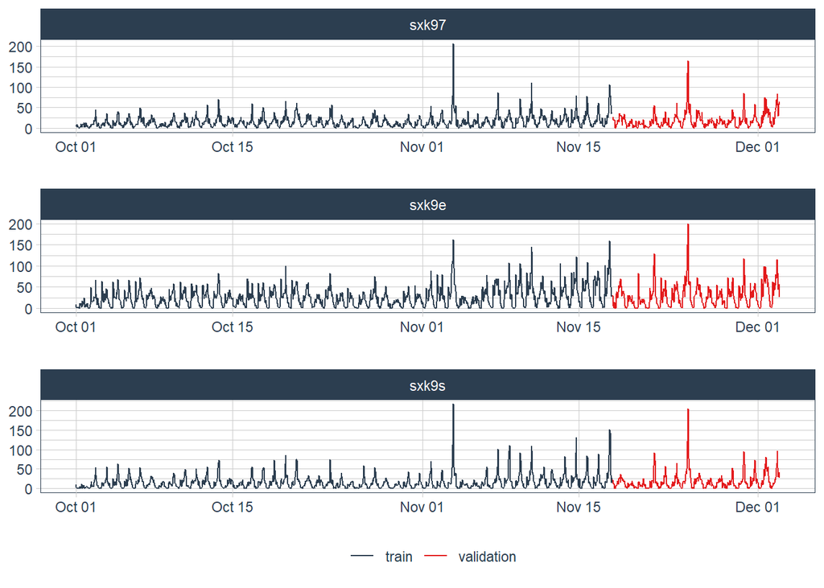

```r
scotty %>%
  mutate(sample = case_when(
    datetime %within% intrain ~ "train",
    datetime %within% inval ~ "validation"
  )) %>%
  mutate(sample = factor(sample, levels = c("train", "validation"))) %>%
  ggplot(aes(x = datetime, y = demand, colour = sample)) +
    geom_line() +
    labs(x = NULL, y = NULL, colour = NULL) +
    facet_wrap(~ src_sub_area, scale = "free", ncol = 1) +
    tidyquant::theme_tq() +
    tidyquant::scale_colour_tq()
```

# 3. Data Preprocess: Square Root Transformation

The first preprocessing is the square root transformation.

First, we spread the data using ‘spread()’ function.

```r
scotty_sqrtscale %<>%
  spread(src_sub_area, demand)

tail(scotty_sqrtscale)
```

```
## # A tibble: 6 x 4
##   datetime            sxk97 sxk9e sxk9s
##   <dttm>              <dbl> <dbl> <dbl>
## 1 2017-12-02 18:00:00    84   115    97
## 2 2017-12-02 19:00:00    56    84    54
## 3 2017-12-02 20:00:00    30    45    30
## 4 2017-12-02 21:00:00    59    57    38
## 5 2017-12-02 22:00:00    64    55    29
## 6 2017-12-02 23:00:00    57    26    41
```

Then, using ‘recipe’, the data is preprocessed using: square root transformation and additionaly center and scale transformation.

```r
# recipes: square root, center, scale
rec <- recipe(~ ., filter(scotty_sqrtscale, datetime %within% intrain)) %>% #filter(scotty_sqrtscale, datetime %within% intrain) does not needed
  step_sqrt(all_numeric()) %>%
  step_center(all_numeric()) %>%
  step_scale(all_numeric()) %>%
  prep()

# preview the bake results
scotty_sqrtscale <- bake(rec, scotty_sqrtscale)
tail(scotty_sqrtscale)
```

```
## # A tibble: 6 x 4
##   datetime            sxk97 sxk9e sxk9s
##   <dttm>              <dbl> <dbl> <dbl>
## 1 2017-12-02 18:00:00  3.18 2.60  3.06
## 2 2017-12-02 19:00:00  2.24 1.94  1.88
## 3 2017-12-02 20:00:00  1.11 0.919 0.993
## 4 2017-12-02 21:00:00  2.35 1.27  1.32
## 5 2017-12-02 22:00:00  2.53 1.21  0.950
## 6 2017-12-02 23:00:00  2.27 0.246 1.43
```

Then, before moving on, we make a function to reverse back the processing ‘rec_revert_sqrtscale’. This is will be useful, we we are analysing the result.

```r
# revert back function
rec_revert_sqrtscale <- function(vector, rec, varname) {

  # store recipe values
  rec_center <- rec$steps[[2]]$means[varname]
  rec_scale <- rec$steps[[3]]$sds[varname]

  # convert back based on the recipe
  results <- (vector * rec_scale + rec_center) ^ 2

  # add additional adjustment if necessary
  results <- round(results)

  # return the results
  results

}
```

Finally, we changed the dataframe into a long format.

```r
scotty_sqrtscale %<>%
  gather(src_sub_area, demand, -datetime)

head(scotty_sqrtscale)
```

```
## # A tibble: 6 x 3
##   datetime            src_sub_area demand
##   <dttm>              <chr>         <dbl>
## 1 2017-10-01 00:00:00 sxk97        -0.593
## 2 2017-10-01 01:00:00 sxk97        -0.845
## 3 2017-10-01 02:00:00 sxk97        -0.283
## 4 2017-10-01 03:00:00 sxk97        -1.17
## 5 2017-10-01 04:00:00 sxk97        -0.713
## 6 2017-10-01 05:00:00 sxk97        -0.845
```

# 4. Data Preprocess: Log Transformation

The second preprocessing is the log transformation.

```r
head(scotty_log)
```

```
## # A tibble: 6 x 3
## # Groups:   src_sub_area [1]
##   src_sub_area datetime            demand
##   <fct>        <dttm>               <dbl>
## 1 sxk97        2017-10-01 00:00:00      6
## 2 sxk97        2017-10-01 01:00:00      4
## 3 sxk97        2017-10-01 02:00:00      9
## 4 sxk97        2017-10-01 03:00:00      2
## 5 sxk97        2017-10-01 04:00:00      5
## 6 sxk97        2017-10-01 05:00:00      4
```

The process is very simple, we only need to do the log transformation of the ‘demand’.

```r
scotty_log$demand <- log(scotty_log$demand)

head(scotty_log)
```

```
## # A tibble: 6 x 3
## # Groups:   src_sub_area [1]
##   src_sub_area datetime            demand
##   <fct>        <dttm>               <dbl>
## 1 sxk97        2017-10-01 00:00:00  1.79
## 2 sxk97        2017-10-01 01:00:00  1.39
## 3 sxk97        2017-10-01 02:00:00  2.20
## 4 sxk97        2017-10-01 03:00:00  0.693
## 5 sxk97        2017-10-01 04:00:00  1.61
## 6 sxk97        2017-10-01 05:00:00  1.39
```

# 5.Cross-validating both transformed data

Now we need to cross-validated both transformed data, and create a nested dataframe to be able to build automated model selection.

First, for the square root scale transformation.

```r
scotty_sqrtscale %<>%
  mutate(set = case_when(
    datetime %within% intrain ~ "train",
    datetime %within% inval ~ "validation"
  ))

head(scotty_sqrtscale)
```

```
## # A tibble: 6 x 4
##   datetime            src_sub_area demand set
##   <dttm>              <chr>         <dbl> <chr>
## 1 2017-10-01 00:00:00 sxk97        -0.593 train
## 2 2017-10-01 01:00:00 sxk97        -0.845 train
## 3 2017-10-01 02:00:00 sxk97        -0.283 train
## 4 2017-10-01 03:00:00 sxk97        -1.17  train
## 5 2017-10-01 04:00:00 sxk97        -0.713 train
## 6 2017-10-01 05:00:00 sxk97        -0.845 train
```

```r
scotty_sqrtscale %<>%
  group_by(src_sub_area, set) %>%
   nest(.key = "data") %>%
   pivot_wider(names_from = set, values_from = data)
scotty_sqrtscale
```

```
## # A tibble: 3 x 3
## # Groups:   src_sub_area [3]
##   src_sub_area          train     validation
##   <chr>        <list<df[,2]>> <list<df[,2]>>
## 1 sxk97           [1,152 x 2]      [360 x 2]
## 2 sxk9e           [1,152 x 2]      [360 x 2]
## 3 sxk9s           [1,152 x 2]      [360 x 2]
```

Secondly, for the log transformed data.

```r
scotty_log %<>%
  mutate(set = case_when(
    datetime %within% intrain ~ "train",
    datetime %within% inval ~ "validation"
  ))

head(scotty_log)
```

```
## # A tibble: 6 x 4
## # Groups:   src_sub_area [1]
##   src_sub_area datetime            demand set
##   <fct>        <dttm>               <dbl> <chr>
## 1 sxk97        2017-10-01 00:00:00  1.79  train
## 2 sxk97        2017-10-01 01:00:00  1.39  train
## 3 sxk97        2017-10-01 02:00:00  2.20  train
## 4 sxk97        2017-10-01 03:00:00  0.693 train
## 5 sxk97        2017-10-01 04:00:00  1.61  train
## 6 sxk97        2017-10-01 05:00:00  1.39  train
```

```r
scotty_log %<>%
  group_by(src_sub_area, set) %>%
   nest(.key = "data") %>%
   pivot_wider(names_from = set, values_from = data)
scotty_log
```

```
## # A tibble: 3 x 3
## # Groups:   src_sub_area [3]
##   src_sub_area          train     validation
##   <fct>        <list<df[,2]>> <list<df[,2]>>
## 1 sxk97           [1,152 x 2]      [360 x 2]
## 2 sxk9e           [1,152 x 2]      [360 x 2]
## 3 sxk9s           [1,152 x 2]      [360 x 2]
```

# 6.Modelling

First, a list containing the time series function is needed to be constructed. ‘ts’ function is designated for time series models with single seasonality, in this case daily, therefore the frequency is 24 for 24 hours. ‘msts’ fuction is designated for time series models with multiple seasonality, in this case daily and weekly, therefore there is an additional frequency of 24 * 7 for 24 hours in 7 days.

```r
data_funs <- list(
  ts = function(x) ts(x$demand, frequency = 24),
  msts = function(x) msts(x$demand, seasonal.periods = c(24, 24 * 7))
)

data_funs
```

```
## $ts
## function(x) ts(x$demand, frequency = 24)
##
## $msts
## function(x) msts(x$demand, seasonal.periods = c(24, 24 * 7))
```

Second, the rows are duplicated for each area ‘src_sub_area’ using ‘rep()’ function. Then, the list is transformed into dataframe by using ‘enframe’. Afterward the area ‘src_sub_area’ is inserted into the table. This is crucial to be able to join ‘data_funs’ and ‘scotty’ based on the area.

```r
data_funs %<>%
  rep(length(unique(scotty$src_sub_area)))%>%
  enframe("data_fun_name", "data_fun") %>%
  mutate(src_sub_area =
    sort(rep(unique(scotty$src_sub_area), length(unique(.$data_fun_name)))))

data_funs
```

```
## # A tibble: 6 x 3
##   data_fun_name data_fun src_sub_area
##   <chr>         <list>   <fct>
## 1 ts            <fn>     sxk97
## 2 msts          <fn>     sxk97
## 3 ts            <fn>     sxk9e
## 4 msts          <fn>     sxk9e
## 5 ts            <fn>     sxk9s
## 6 msts          <fn>     sxk9s
```

Third, join ‘data_fun’ and ‘scotty_sqrtscale’, as well as ‘scotty_log’

```r
scotty_sqrtscale %<>%
  left_join(data_funs)
scotty_log %<>%
  left_join(data_funs)
scotty_sqrtscale
```

```
## # A tibble: 6 x 5
## # Groups:   src_sub_area [3]
##   src_sub_area          train     validation data_fun_name data_fun
##   <chr>        <list<df[,2]>> <list<df[,2]>> <chr>         <list>
## 1 sxk97           [1,152 x 2]      [360 x 2] ts            <fn>
## 2 sxk97           [1,152 x 2]      [360 x 2] msts          <fn>
## 3 sxk9e           [1,152 x 2]      [360 x 2] ts            <fn>
## 4 sxk9e           [1,152 x 2]      [360 x 2] msts          <fn>
## 5 sxk9s           [1,152 x 2]      [360 x 2] ts            <fn>
## 6 sxk9s           [1,152 x 2]      [360 x 2] msts          <fn>
```

```r
scotty_log
```

```
## # A tibble: 6 x 5
## # Groups:   src_sub_area [3]
##   src_sub_area          train     validation data_fun_name data_fun
##   <fct>        <list<df[,2]>> <list<df[,2]>> <chr>         <list>
## 1 sxk97           [1,152 x 2]      [360 x 2] ts            <fn>
## 2 sxk97           [1,152 x 2]      [360 x 2] msts          <fn>
## 3 sxk9e           [1,152 x 2]      [360 x 2] ts            <fn>
## 4 sxk9e           [1,152 x 2]      [360 x 2] msts          <fn>
## 5 sxk9s           [1,152 x 2]      [360 x 2] ts            <fn>
## 6 sxk9s           [1,152 x 2]      [360 x 2] msts          <fn>
```

Fourth, a list of the time series models, for this project

```r
models <- list(
  auto.arima = function(x) auto.arima(x),
  ets = function(x) ets(x),
  stlm = function(x) stlm(x),
  tbats = function(x) tbats(x, use.box.cox = FALSE),
  holt.winter = function(x) HoltWinters(x,seasonal = "additive")
)

models
```

```
## $auto.arima
## function(x) auto.arima(x)
##
## $ets
## function(x) ets(x)
##
## $stlm
## function(x) stlm(x)
##
## $tbats
## function(x) tbats(x, use.box.cox = FALSE)
##
## $holt.winter
## function(x) HoltWinters(x,seasonal = "additive")
```

Fifth, similar to the ‘data_funs’ list. The rows of ‘models’ are duplicated for each area ‘src_sub_area’ using ‘rep()’ function. Then, the list is transformed into dataframe by using ‘enframe’. Afterward the area ‘src_sub_area’ is inserted into the table. This is crucial to be able to join ‘models’ and ‘scotty_sqrtscale’, as well as ‘scotty_log’ based on the area.

```r
models %<>%
  rep(length(unique(scotty$src_sub_area))) %>%
  enframe("model_name", "model") %>%
  mutate(src_sub_area =
    sort(rep(unique(scotty$src_sub_area), length(unique(.$model_name))))
  )

models
```

```
## # A tibble: 15 x 3
##    model_name  model  src_sub_area
##    <chr>       <list> <fct>
##  1 auto.arima  <fn>   sxk97
##  2 ets         <fn>   sxk97
##  3 stlm        <fn>   sxk97
##  4 tbats       <fn>   sxk97
##  5 holt.winter <fn>   sxk97
##  6 auto.arima  <fn>   sxk9e
##  7 ets         <fn>   sxk9e
##  8 stlm        <fn>   sxk9e
##  9 tbats       <fn>   sxk9e
## 10 holt.winter <fn>   sxk9e
## 11 auto.arima  <fn>   sxk9s
## 12 ets         <fn>   sxk9s
## 13 stlm        <fn>   sxk9s
## 14 tbats       <fn>   sxk9s
## 15 holt.winter <fn>   sxk9s
```

Sixth, ‘models’ and ‘scotty_sqrtscale’, as well as ‘scotty_log’ are joint. However, auto.arima and ets are not suitable for a multiple seasonality time series modeling. Therefore, ‘filter’ function is used to make sure the models are not included into the time series forecasing for multiple seasonality.

```r
scotty_sqrtscale %<>%
  left_join(models) %>%
  filter(
    !(model_name == "ets" & data_fun_name == "msts"),
    !(model_name == "auto.arima" & data_fun_name == "msts")
  )
scotty_log %<>%
  left_join(models) %>%
  filter(
    !(model_name == "ets" & data_fun_name == "msts"),
    !(model_name == "auto.arima" & data_fun_name == "msts")
  )
scotty_sqrtscale
```

```
## # A tibble: 24 x 7
## # Groups:   src_sub_area [3]
##    src_sub_area        train  validation data_fun_name data_fun model_name model
##    <chr>        <list<df[,2> <list<df[,> <chr>         <list>   <chr>      <lis>
##  1 sxk97         [1,152 x 2]   [360 x 2] ts            <fn>     auto.arima <fn>
##  2 sxk97         [1,152 x 2]   [360 x 2] ts            <fn>     ets        <fn>
##  3 sxk97         [1,152 x 2]   [360 x 2] ts            <fn>     stlm       <fn>
##  4 sxk97         [1,152 x 2]   [360 x 2] ts            <fn>     tbats      <fn>
##  5 sxk97         [1,152 x 2]   [360 x 2] ts            <fn>     holt.wint~ <fn>
##  6 sxk97         [1,152 x 2]   [360 x 2] msts          <fn>     stlm       <fn>
##  7 sxk97         [1,152 x 2]   [360 x 2] msts          <fn>     tbats      <fn>
##  8 sxk97         [1,152 x 2]   [360 x 2] msts          <fn>     holt.wint~ <fn>
##  9 sxk9e         [1,152 x 2]   [360 x 2] ts            <fn>     auto.arima <fn>
## 10 sxk9e         [1,152 x 2]   [360 x 2] ts            <fn>     ets        <fn>
## # ... with 14 more rows
```

```r
scotty_log
```

```
## # A tibble: 24 x 7
## # Groups:   src_sub_area [3]
##    src_sub_area        train  validation data_fun_name data_fun model_name model
##    <fct>        <list<df[,2> <list<df[,> <chr>         <list>   <chr>      <lis>
##  1 sxk97         [1,152 x 2]   [360 x 2] ts            <fn>     auto.arima <fn>
##  2 sxk97         [1,152 x 2]   [360 x 2] ts            <fn>     ets        <fn>
##  3 sxk97         [1,152 x 2]   [360 x 2] ts            <fn>     stlm       <fn>
##  4 sxk97         [1,152 x 2]   [360 x 2] ts            <fn>     tbats      <fn>
##  5 sxk97         [1,152 x 2]   [360 x 2] ts            <fn>     holt.wint~ <fn>
##  6 sxk97         [1,152 x 2]   [360 x 2] msts          <fn>     stlm       <fn>
##  7 sxk97         [1,152 x 2]   [360 x 2] msts          <fn>     tbats      <fn>
##  8 sxk97         [1,152 x 2]   [360 x 2] msts          <fn>     holt.wint~ <fn>
##  9 sxk9e         [1,152 x 2]   [360 x 2] ts            <fn>     auto.arima <fn>
## 10 sxk9e         [1,152 x 2]   [360 x 2] ts            <fn>     ets        <fn>
## # ... with 14 more rows
```

Seventh, to do the model fitting, we create a list (‘param’) of the train dataset using map(). Then, the time series object is created and saved in ‘data’ and then, it is moved to ‘params’. Afterwards, the model is created by invoking the function in ‘model’ using the data in ‘params’

```r
scotty_sqrtscale %<>%
  mutate(
    params = map(train, ~ list(x = .x)),
    data = invoke_map(data_fun, params),
    params = map(data, ~ list(x = .x)),
    fitted = invoke_map(model, params)) %>%
  select(-data, -params)

scotty_sqrtscale
```

```
## # A tibble: 24 x 8
## # Groups:   src_sub_area [3]
##    src_sub_area       train validation data_fun_name data_fun model_name model
##    <chr>        <list<df[,> <list<df[> <chr>         <list>   <chr>      <lis>
##  1 sxk97        [1,152 x 2]  [360 x 2] ts            <fn>     auto.arima <fn>
##  2 sxk97        [1,152 x 2]  [360 x 2] ts            <fn>     ets        <fn>
##  3 sxk97        [1,152 x 2]  [360 x 2] ts            <fn>     stlm       <fn>
##  4 sxk97        [1,152 x 2]  [360 x 2] ts            <fn>     tbats      <fn>
##  5 sxk97        [1,152 x 2]  [360 x 2] ts            <fn>     holt.wint~ <fn>
##  6 sxk97        [1,152 x 2]  [360 x 2] msts          <fn>     stlm       <fn>
##  7 sxk97        [1,152 x 2]  [360 x 2] msts          <fn>     tbats      <fn>
##  8 sxk97        [1,152 x 2]  [360 x 2] msts          <fn>     holt.wint~ <fn>
##  9 sxk9e        [1,152 x 2]  [360 x 2] ts            <fn>     auto.arima <fn>
## 10 sxk9e        [1,152 x 2]  [360 x 2] ts            <fn>     ets        <fn>
## # ... with 14 more rows, and 1 more variable: fitted <list>
```

```r
scotty_log %<>%
  mutate(
    params = map(train, ~ list(x = .x)),
    data = invoke_map(data_fun, params),
    params = map(data, ~ list(x = .x)),
    fitted = invoke_map(model, params)) %>%
  select(-data, -params)

scotty_log
```

```
## # A tibble: 24 x 8
## # Groups:   src_sub_area [3]
##    src_sub_area       train validation data_fun_name data_fun model_name model
##    <fct>        <list<df[,> <list<df[> <chr>         <list>   <chr>      <lis>
##  1 sxk97        [1,152 x 2]  [360 x 2] ts            <fn>     auto.arima <fn>
##  2 sxk97        [1,152 x 2]  [360 x 2] ts            <fn>     ets        <fn>
##  3 sxk97        [1,152 x 2]  [360 x 2] ts            <fn>     stlm       <fn>
##  4 sxk97        [1,152 x 2]  [360 x 2] ts            <fn>     tbats      <fn>
##  5 sxk97        [1,152 x 2]  [360 x 2] ts            <fn>     holt.wint~ <fn>
##  6 sxk97        [1,152 x 2]  [360 x 2] msts          <fn>     stlm       <fn>
##  7 sxk97        [1,152 x 2]  [360 x 2] msts          <fn>     tbats      <fn>
##  8 sxk97        [1,152 x 2]  [360 x 2] msts          <fn>     holt.wint~ <fn>
##  9 sxk9e        [1,152 x 2]  [360 x 2] ts            <fn>     auto.arima <fn>
## 10 sxk9e        [1,152 x 2]  [360 x 2] ts            <fn>     ets        <fn>
## # ... with 14 more rows, and 1 more variable: fitted <list>
```

Eight, the error from the models for both preprocessed data are calculated, in this case we are calculating and comparing the MAE (Mean absolute error)

```r
scotty_sqrtscale %<>%
  mutate(error =
    map(fitted, ~ forecast(.x, h = 24 * 15)) %>%
    map2_dbl(validation, ~ mae_vec(truth = rec_revert_sqrtscale(.y$demand,rec,src_sub_area), estimate = rec_revert_sqrtscale(.x$mean,rec,src_sub_area)))) %>%
  arrange(src_sub_area, error)

scotty_sqrtscale
```

```
## # A tibble: 24 x 9
## # Groups:   src_sub_area [3]
##    src_sub_area       train validation data_fun_name data_fun model_name model
##    <chr>        <list<df[,> <list<df[> <chr>         <list>   <chr>      <lis>
##  1 sxk97        [1,152 x 2]  [360 x 2] msts          <fn>     tbats      <fn>
##  2 sxk97        [1,152 x 2]  [360 x 2] msts          <fn>     stlm       <fn>
##  3 sxk97        [1,152 x 2]  [360 x 2] ts            <fn>     tbats      <fn>
##  4 sxk97        [1,152 x 2]  [360 x 2] ts            <fn>     auto.arima <fn>
##  5 sxk97        [1,152 x 2]  [360 x 2] msts          <fn>     holt.wint~ <fn>
##  6 sxk97        [1,152 x 2]  [360 x 2] ts            <fn>     ets        <fn>
##  7 sxk97        [1,152 x 2]  [360 x 2] ts            <fn>     stlm       <fn>
##  8 sxk97        [1,152 x 2]  [360 x 2] ts            <fn>     holt.wint~ <fn>
##  9 sxk9e        [1,152 x 2]  [360 x 2] msts          <fn>     stlm       <fn>
## 10 sxk9e        [1,152 x 2]  [360 x 2] msts          <fn>     tbats      <fn>
## # ... with 14 more rows, and 2 more variables: fitted <list>, error <dbl>
```

```r
scotty_log %<>%
  mutate(error =
    map(fitted, ~ forecast(.x, h = 24 * 15)) %>%
    map2_dbl(validation, ~ mae_vec(truth = exp(.y$demand), estimate = exp(.x$mean)))) %>%
  arrange(src_sub_area, error)

scotty_log
```

```
## # A tibble: 24 x 9
## # Groups:   src_sub_area [3]
##    src_sub_area       train validation data_fun_name data_fun model_name model
##    <fct>        <list<df[,> <list<df[> <chr>         <list>   <chr>      <lis>
##  1 sxk97        [1,152 x 2]  [360 x 2] msts          <fn>     stlm       <fn>
##  2 sxk97        [1,152 x 2]  [360 x 2] msts          <fn>     tbats      <fn>
##  3 sxk97        [1,152 x 2]  [360 x 2] ts            <fn>     tbats      <fn>
##  4 sxk97        [1,152 x 2]  [360 x 2] ts            <fn>     auto.arima <fn>
##  5 sxk97        [1,152 x 2]  [360 x 2] msts          <fn>     holt.wint~ <fn>
##  6 sxk97        [1,152 x 2]  [360 x 2] ts            <fn>     ets        <fn>
##  7 sxk97        [1,152 x 2]  [360 x 2] ts            <fn>     stlm       <fn>
##  8 sxk97        [1,152 x 2]  [360 x 2] ts            <fn>     holt.wint~ <fn>
##  9 sxk9e        [1,152 x 2]  [360 x 2] msts          <fn>     stlm       <fn>
## 10 sxk9e        [1,152 x 2]  [360 x 2] msts          <fn>     tbats      <fn>
## # ... with 14 more rows, and 2 more variables: fitted <list>, error <dbl>
```

Lastly, we chose the three best models from both transformed data for every area ‘src_sub_area’.

For square root transformed data:

```r
scotty_sqrtscale %<>%
  select(-fitted) %>% # remove unused
  group_by(src_sub_area) %>%
  filter(error == min(error)) %>%
  ungroup()

scotty_sqrtscale
```

```
## # A tibble: 3 x 8
##   src_sub_area       train validation data_fun_name data_fun model_name model
##   <chr>        <list<df[,> <list<df[> <chr>         <list>   <chr>      <lis>
## 1 sxk97        [1,152 x 2]  [360 x 2] msts          <fn>     tbats      <fn>
## 2 sxk9e        [1,152 x 2]  [360 x 2] msts          <fn>     stlm       <fn>
## 3 sxk9s        [1,152 x 2]  [360 x 2] msts          <fn>     tbats      <fn>
## # ... with 1 more variable: error <dbl>
```

For log transformed data:

```r
scotty_log %<>%
  select(-fitted) %>% # remove unused
  group_by(src_sub_area) %>%
  filter(error == min(error)) %>%
  ungroup()

scotty_log
```

```
## # A tibble: 3 x 8
##   src_sub_area       train validation data_fun_name data_fun model_name model
##   <fct>        <list<df[,> <list<df[> <chr>         <list>   <chr>      <lis>
## 1 sxk97        [1,152 x 2]  [360 x 2] msts          <fn>     stlm       <fn>
## 2 sxk9e        [1,152 x 2]  [360 x 2] msts          <fn>     stlm       <fn>
## 3 sxk9s        [1,152 x 2]  [360 x 2] msts          <fn>     tbats      <fn>
## # ... with 1 more variable: error <dbl>
```

We will used the square root transformed data, with above mentioned models, Because by using those methods, it shows the overall lowest MAE, compared using the log transformed data.

# 7. Forecasting using Test Dataset

Now we will forecast the data for the dataset: which is 7 days additional of the latest day in the validation date.

Because the model we made was using the train data, therefore for this case we will forecast using the train data only.

```r
scotty_sqrtscale %<>%
  mutate(
    params = map(train, ~ list(x = .x)), # fulll data
    data = invoke_map(data_fun, params),
    params = map(data, ~ list(x = .x)),
    fitted = invoke_map(model, params)
  ) %>%
  select(-data, -params)

scotty_sqrtscale
```

```
## # A tibble: 3 x 9
##   src_sub_area       train validation data_fun_name data_fun model_name model
##   <chr>        <list<df[,> <list<df[> <chr>         <list>   <chr>      <lis>
## 1 sxk97        [1,152 x 2]  [360 x 2] msts          <fn>     tbats      <fn>
## 2 sxk9e        [1,152 x 2]  [360 x 2] msts          <fn>     stlm       <fn>
## 3 sxk9s        [1,152 x 2]  [360 x 2] msts          <fn>     tbats      <fn>
## # ... with 2 more variables: error <dbl>, fitted <list>
```

We will forecast for 22 days because we are using the train dataset only (15 days is the length of the validationd dataset, 7 days is the lenght of the test dataset).

```r
scotty_sqrtscale %<>%
  mutate(forecast =
    map(fitted, ~ forecast(.x, h = 24 * 22)) %>%
    map2(train, ~ tibble(
      datetime = timetk::tk_make_future_timeseries(.y$datetime, 24 * 22), demand = as.vector(.x$mean)
    ))
  )

scotty_sqrtscale
```

```
## # A tibble: 3 x 10
##   src_sub_area       train validation data_fun_name data_fun model_name model
##   <chr>        <list<df[,> <list<df[> <chr>         <list>   <chr>      <lis>
## 1 sxk97        [1,152 x 2]  [360 x 2] msts          <fn>     tbats      <fn>
## 2 sxk9e        [1,152 x 2]  [360 x 2] msts          <fn>     stlm       <fn>
## 3 sxk9s        [1,152 x 2]  [360 x 2] msts          <fn>     tbats      <fn>
## # ... with 3 more variables: error <dbl>, fitted <list>, forecast <list>
```

```r
scotty_sqrtscale_analysis <- scotty_sqrtscale
```

Then, we unnest the value.

```r
scotty_sqrtscale %<>%
  select(src_sub_area, actual = train, forecast) %>%
  gather(key, value, -src_sub_area) %>%
  unnest(value) %>%
  mutate(demand = rec_revert_sqrtscale(demand, rec, src_sub_area))
head(scotty_sqrtscale)
```

```
## # A tibble: 6 x 4
##   src_sub_area key    datetime            demand
##   <chr>        <chr>  <dttm>               <dbl>
## 1 sxk97        actual 2017-10-01 00:00:00      6
## 2 sxk97        actual 2017-10-01 01:00:00      4
## 3 sxk97        actual 2017-10-01 02:00:00      9
## 4 sxk97        actual 2017-10-01 03:00:00      2
## 5 sxk97        actual 2017-10-01 04:00:00      5
## 6 sxk97        actual 2017-10-01 05:00:00      4
```

Afterwards, we create the forecasted data

```r
scotty_sqrtscale_forecast <- scotty_sqrtscale %>%
  filter(key == "forecast") %>%
   select(-key)

head(scotty_sqrtscale_forecast)
```

```
## # A tibble: 6 x 3
##   src_sub_area datetime            demand
##   <chr>        <dttm>               <dbl>
## 1 sxk97        2017-11-18 00:00:00     30
## 2 sxk97        2017-11-18 01:00:00     21
## 3 sxk97        2017-11-18 02:00:00     15
## 4 sxk97        2017-11-18 03:00:00     10
## 5 sxk97        2017-11-18 04:00:00      6
## 6 sxk97        2017-11-18 05:00:00      5
```

We take the data only for the latest 7 days.

```r
# train-val-test size
test_size <- 24 * 7 # 15 from 62 days

# get the min-max of the time index for each sample
test_end <- max(scotty_sqrtscale_forecast$datetime)
test_start <- test_end - hours(test_size) + hours(1)

intest <- interval(test_start, test_end)

intest
```

```
## [1] 2017-12-03 UTC--2017-12-09 23:00:00 UTC
```

```r
scotty_sqrtscale_forecast %<>%
  mutate(sample = case_when(
    datetime %within% intest ~ "test"
  ))

head(scotty_sqrtscale_forecast)
```

```
## # A tibble: 6 x 4
##   src_sub_area datetime            demand sample
##   <chr>        <dttm>               <dbl> <chr>
## 1 sxk97        2017-11-18 00:00:00     30 <NA>
## 2 sxk97        2017-11-18 01:00:00     21 <NA>
## 3 sxk97        2017-11-18 02:00:00     15 <NA>
## 4 sxk97        2017-11-18 03:00:00     10 <NA>
## 5 sxk97        2017-11-18 04:00:00      6 <NA>
## 6 sxk97        2017-11-18 05:00:00      5 <NA>
```

```r
scotty_sqrtscale_forecast %<>%
  filter(sample == "test")

head(scotty_sqrtscale_forecast)
```

```
## # A tibble: 6 x 4
##   src_sub_area datetime            demand sample
##   <chr>        <dttm>               <dbl> <chr>
## 1 sxk97        2017-12-03 00:00:00     25 test
## 2 sxk97        2017-12-03 01:00:00     18 test
## 3 sxk97        2017-12-03 02:00:00     13 test
## 4 sxk97        2017-12-03 03:00:00      9 test
## 5 sxk97        2017-12-03 04:00:00      6 test
## 6 sxk97        2017-12-03 05:00:00      4 test
```

Finally, the data is inserted into test dataset.

```r
scotty_test <- read.csv("data/data-test.csv")

head(scotty_test)
```

```
##   X src_sub_area            datetime demand
## 1 1        sxk97 2017-12-03 00:00:00     25
## 2 2        sxk97 2017-12-03 01:00:00     18
## 3 3        sxk97 2017-12-03 02:00:00     13
## 4 4        sxk97 2017-12-03 03:00:00      9
## 5 5        sxk97 2017-12-03 04:00:00      6
## 6 6        sxk97 2017-12-03 05:00:00      4
```

```r
scotty_test$datetime <- ymd_hms(scotty_test$datetime)

head(scotty_test)
```

```
##   X src_sub_area            datetime demand
## 1 1        sxk97 2017-12-03 00:00:00     25
## 2 2        sxk97 2017-12-03 01:00:00     18
## 3 3        sxk97 2017-12-03 02:00:00     13
## 4 4        sxk97 2017-12-03 03:00:00      9
## 5 5        sxk97 2017-12-03 04:00:00      6
## 6 6        sxk97 2017-12-03 05:00:00      4
```

```r
scotty_test$demand = scotty_sqrtscale_forecast$demand
```

```r
head(scotty_test)
```

```
##   X src_sub_area            datetime demand
## 1 1        sxk97 2017-12-03 00:00:00     25
## 2 2        sxk97 2017-12-03 01:00:00     18
## 3 3        sxk97 2017-12-03 02:00:00     13
## 4 4        sxk97 2017-12-03 03:00:00      9
## 5 5        sxk97 2017-12-03 04:00:00      6
## 6 6        sxk97 2017-12-03 05:00:00      4
```

```r
write.csv(scotty_test,"data/data-test.csv")
```

# 8. Conclusion

By inserting the data-test.csv to Algoritma Leaderboard Score site, I received, below errors for data input on 29 & 31 of March 2020: 1. MAE for sxk97 area is 7.26 by using tbats method 2. MAE for sxk9e area is 8.47 by using stlm method 3. MAE for sxk9s area is 7.39 by using tbats method

And overall MAE is 7.71. This is for the data transformed using square root transformation.

These are the best models for this project is: 1.for sxk97 area is 7.26 by using tbats method 2.for sxk9e area is 8.47 by using stlm method 3. for sxk9s area is 7.39 by using tbats method. And combined with square root preprocessing.